## Exemple: Injecció

En una planta de fabricación de piezas de plástico por inyección se realizó un experimento para reducir el número de rugosidades (“mark flows”) que aparecían en las piezas. Cada prueba consistió en fabricar 100 piezas y obtener el número medio de rugosidades (contadas de una forma normalizada) que aparecían.

Se decidió estudiar los 8 factores siguientes, todos ellos a 2 niveles, uno bajo (–) y otro alto (+):

- A: Recorrido de inyección
- B: Temperatura del molde
- C: Temperatura del fundido
- D: Apertura de la boquilla
- E: 1ª Velocidad de inyección
- F: 2ª Velocidad de inyección
- G: Punto de cambio (inyec./mante.)
- H: Fuerza de cierre del molde

El diseño experimental utilizado fue un 2<sup>8-4</sup> con los experimentos seleccionados con `FrF2`. Los resultados obtenidos, en el orden estándar de la matriz de diseño, fueron

```r
resposta = c(6.2, 5.2, 4.3, 3.0, 5.3, 4.0, 0.0,
             1.9, 6.3, 5.8, 6.0, 3.0, 3.3, 5.8,
             0.0, 0.0)
```

**Solució:** Creem la matriu de disseny i hi afegim la resposta

```r
library(FrF2)
dis = FrF2(nruns = 16, nfactors = 8,
           randomize = FALSE)

resposta = c(6.2, 5.2, 4.3, 3.0, 5.3, 4.0, 0.0,
             1.9, 6.3, 5.8, 6.0, 3.0, 3.3, 5.8,
             0.0, 0.0)
dis = add.response(dis, resposta)
```

És un disseny de resolució IV: hi ha interaccions de dos factors confoses entre elles

```r
aliasprint(dis)
```

```
## $legend
## [1] A=A B=B C=C D=D E=E F=F G=G H=H
##
## $main
## character(0)
##
## $fi2
## [1] AB=CE=DF=GH AC=BE=DG=FH AD=BF=CG=EH AE=BC=DH=FG AF=BD=CH=EG AG=BH=CD=EF
## [7] AH=BG=CF=DE
```

Fem el Daniel plot i identifiquem la temperatura del motlle i la fundició com a importants

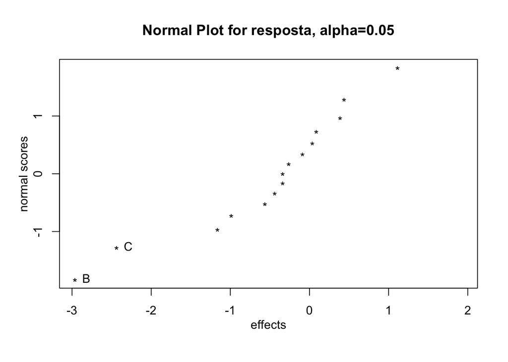

```r
DanielPlot(dis)
```

Ajustem el model amb les temperatures com a predictores, i veiem que són significatives

```r
mod = aov(resposta ~ B + C, dis)
summary(mod)
```

```
##             Df Sum Sq Mean Sq F value   Pr(>F)
## B            1  35.11   35.11   24.14 0.000284 ***
## C            1  23.77   23.77   16.34 0.001397 **
## Residuals   13  18.91    1.45
## ---
## Signif. codes:  0 '***' 0.001 '**' 0.01 '*' 0.05 '.' 0.1 ' ' 1
```

Fem el gràfic d’efectes

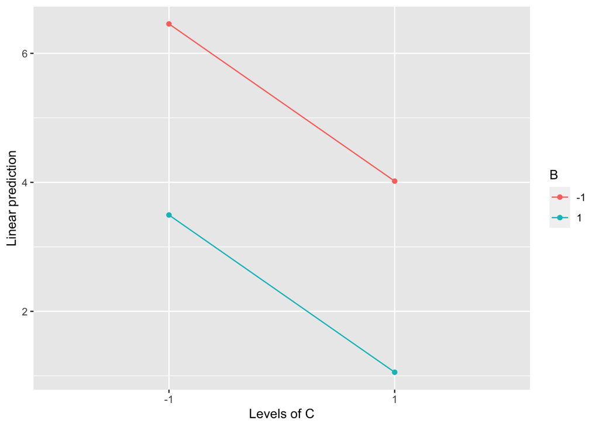

```r
library(emmeans)
emmip(mod, B ~ C)
```

Si volem minimitzar la resposta, recomanem que B = C = 1. És a dir, volem que les temperatures siguin altes. Si volem continuar experimentant, podríem provar temperatures més altes.

## Afegir noms dels nivells del factor

Amb `FrF2`, podem afegir els noms dels nivells, si en tenim. Per exemple:

```r
disseny2 = FrF2(nruns = 16, nfactors = 5,
                randomize = FALSE,
                factor.names =
                  list(temp = c("150", "200"),
                       visco = c("1", "2"),
                       conc = c("20", "30"),
                       pres = c("2", "4"),
                       tipus = c("A", "B")))
disseny2
```

```
##    temp visco conc pres tipus
## 1   150     1   20    2     B
## 2   200     1   20    2     A
## 3   150     2   20    2     A
## 4   200     2   20    2     B
## 5   150     1   30    2     A
## 6   200     1   30    2     B
## 7   150     2   30    2     B
## 8   200     2   30    2     A
## 9   150     1   20    4     A
## 10  200     1   20    4     B
## 11  150     2   20    4     B
## 12  200     2   20    4     A
## 13  150     1   30    4     B
## 14  200     1   30    4     A
## 15  150     2   30    4     A
## 16  200     2   30    4     B
## class=design, type= FrF2
```

## Etiquetes de cava

Creem la matriu de disseny i hi afegim la resposta

```r
library(FrF2)
disseny = FrF2(nruns = 8, nfactors = 5,
               randomize = FALSE)
resposta = c(24, 16, 22.5, 24.5,
             25, 16, 24.5, 23.5)
disseny = add.response(disseny, resposta)
```

És un disseny de resolució III: hi ha efectes principals confosos amb interaccions de dues variables.

```r
aliasprint(disseny)
```

```
## $legend
## [1] A=A B=B C=C D=D E=E
##
## $main
## [1] A=BD=CE B=AD    C=AE    D=AB    E=AC
##
## $fi2
## [1] BC=DE BE=CD
```

Fem el Daniel plot

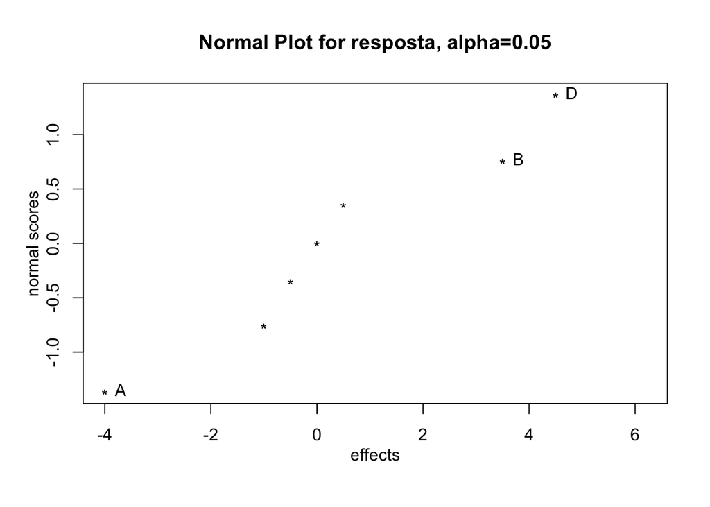

```r
DanielPlot(disseny)
```

Ens surten A, B i D com a importants. Hem d’anar amb compte, però, perquè és un disseny fraccional i hi ha confusions:

- A està confosa amb les interaccions BD i CE
- B està confosa amb la interacció AD
- D està confusa amb la interacció AB

Sembla poc probable que CE sigui realment important, donat que els efectes de C i E no apareixen enlloc més. Per tant, amb les dades que tenim, els models següents semblen raonables:

- A + B + D
- A + B + AB
- A + D + AD
- B + D + BD

Amb les dades que tenim, aquests models no es poden distingir. Si feu les taules ANOVA d’aquests quatre models, veureu que són idèntiques. El que sí que sembla clar és que els factors C i E no són importants.

Si treballem amb un enginyer que ens digui quin model és el “bo”, en podríem triar un. Si no és el cas, recomanem fer un disseny complet $2^3$ amb els factors A, B i D. Recordeu que els dissenys complets poden distingir els quatre models que hem identificat com interessants perquè no tenen confusions.

## Vernís

Creem la matriu de disseny i hi afegim la resposta

```r
disseny2 = FrF2(nruns = 16, nfactors = 5,
                randomize = FALSE,
                factor.names =
                  list(temp = c("150", "200"),
                       visco = c("1", "2"),
                       conc = c("20", "30"),
                       pres = c("2", "4"),
                       tipus = c("A", "B")))

resposta = c(55.5, 44.5, 42.0, 48.0,
             58.0, 46.0, 41.5, 48.5,
             48.0, 37.8, 32.9, 38.5,
             46.5, 38.5, 30.0, 39.0)

disseny2 = add.response(disseny2, resposta)
```

`FrF2` només ens identifica confusions d’efectes principals amb interaccions de dues variables i confusions d’interaccions de dues variables entre elles. En aquest cas, no en troba cap, de confusió. Per tant, el disseny és de resolució V, com a mínim.

```r
aliasprint(disseny2)
```

```
## $legend
## [1] A=temp  B=visco C=conc  D=pres  E=tipus
##
## [[2]]
## [1] no aliasing among main effects and 2fis
```

Als dissenys de resolució V, hi ha interaccions de tres variables confoses amb interaccions de dues. Com que normalment ignorem les interaccions de tres variables (a no ser que tinguem motius molt bons per saber que existeixen), els dissenys de resolució V són, a efectes pràctics, com si fossin complets.

Fem un Daniel plot:

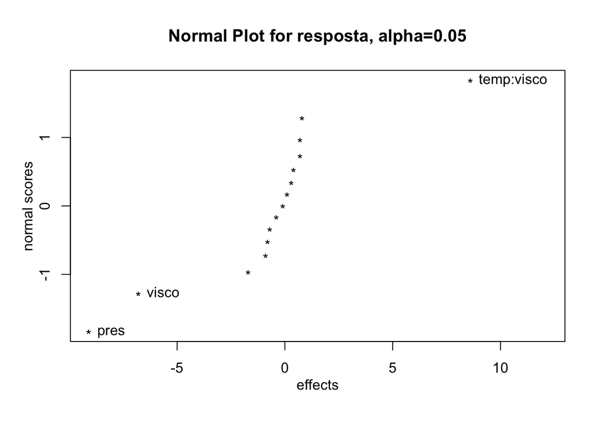

```r
DanielPlot(disseny2)
```

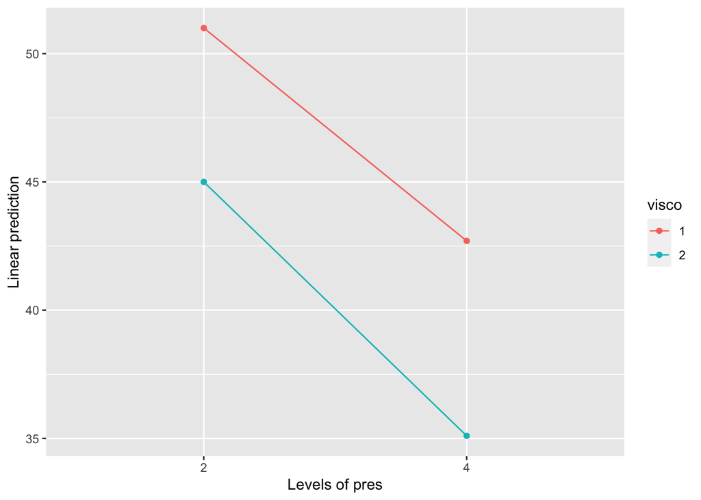

```r
library(emmeans)
mod2 = aov(resposta ~ visco*pres, disseny2)
emmip(mod2, visco ~ pres)
```

## Gelats

Creem la matriu de disseny i hi afegim la resposta

```r
dis_gelat = FrF2(nruns = 8, nfactors = 4,
                 randomize = FALSE)
resposta = c(29.63, 31.91, 33.02, 25.55,
             27.28, 32.35, 34.39, 24.72)

dis_gelat = add.response(dis_gelat, resposta)
```

És un disseny de resolució IV amb les següents confusions

```r
aliasprint(dis_gelat)
```

```
## $legend
## [1] A=A B=B C=C D=D
##
## $main
## character(0)
##
## $fi2
## [1] AB=CD AC=BD AD=BC
```

Fem el Daniel plot:

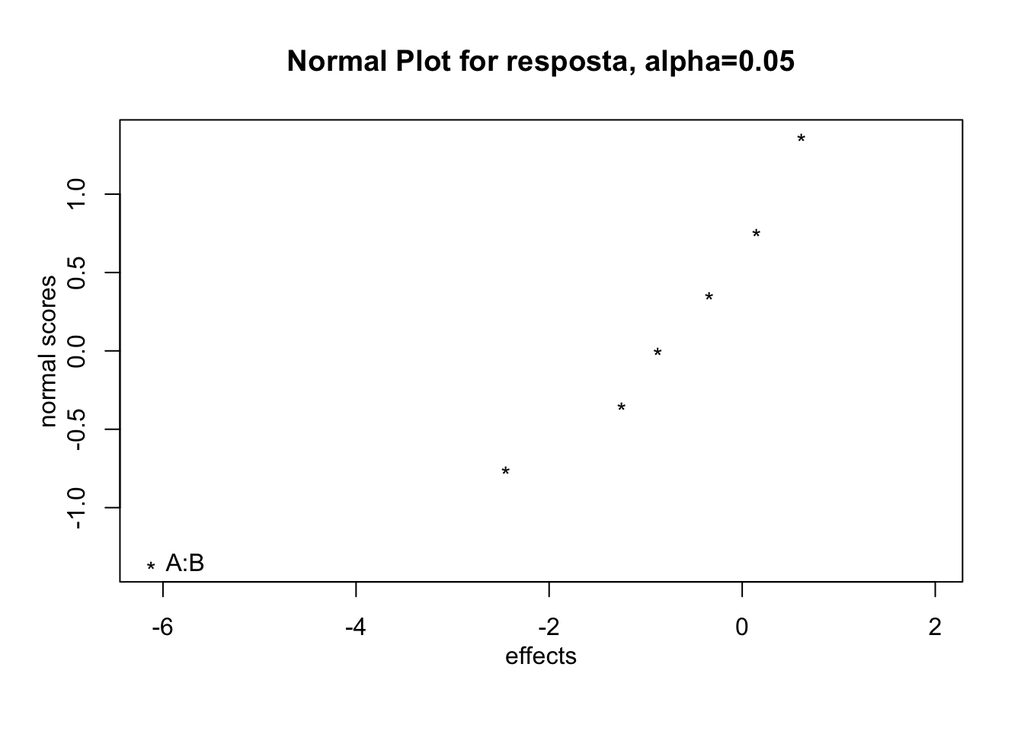

```r
DanielPlot(dis_gelat)
```

El gràfic identifica AB com a important. La interacció AB està confosa amb la interacció CD. L’enunciat ens diu que és poc probable que hi hagi una interacció entre temperatura de congelació (C) i el temps d’emmagatzematge (D). Per tant, ajustem el model amb AB i ens el creiem.

```r
mod = aov(resposta ~ A*B, data = dis_gelat)
```

Mirant el gràfic de mitjanes estimades, recomanem fer els gelats amb llet sencera i a potència 500 W. Si volem continuar experimentant, podríem provar potències més altes.

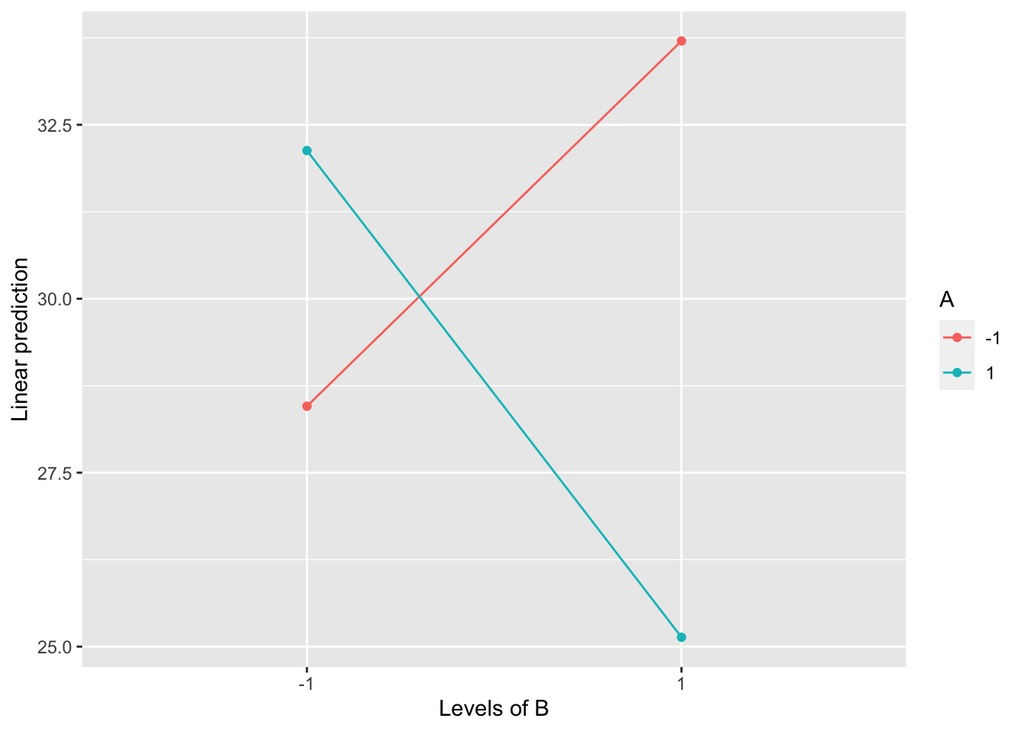

```r
emmip(mod, A ~ B)
```